# Recommendations to a Government Manager on the Preparation for Severe Weather Events

## *Data Processing*

```r
library(R.utils)
library(data.table)
library(ggplot2)
library(gridExtra)
library(dplyr)
library(quantmod)
library(knitr)
```

### Downloading, Extracting and Saving the Dataset

The dataset is available at the link [NOAA Storm Database](https://d396qusza40orc.cloudfront.net/repdata%2Fdata%2FStormData.csv.bz2) from the Coursera’s Reproducible Research course repository. It contains severe weather data events from 1950 to 2011. The comma-separated-value file was compressed via the bzip2 algorithm to reduce its size.

The data file is downloaded, extracted and saved at the working directory using the R code:

```r
download.file("http://d396qusza40orc.cloudfront.net/repdata%2Fdata%2FStormData.csv.bz2", destfile="rawdata.csv.bz2")
bunzip2("rawdata.csv.bz2", overwrite=T, remove=F)
```

Then the raw data is loaded in R:

```r
rawdata <- read.csv("rawdata.csv")
```

A data table is created using the function data.table that inherits data.frame. It offers fast subset, fast grouping, fast update, fast ordered joins and list columns in a short and flexible syntax, for faster development. Source: R Documentation on the data.tablepackage {data.table}.

```r
rawdata = data.table(rawdata)
```

The raw dataset contains 902297 rows with data collected between JAN-1950 and NOV-2011.

```r
dim(rawdata)
```

```
## [1] 902297     37
```

There are few events captured in the earlier years due to a lack of good records. Most recent years should be considered more complete. The summarization of events per year is made using the code below:

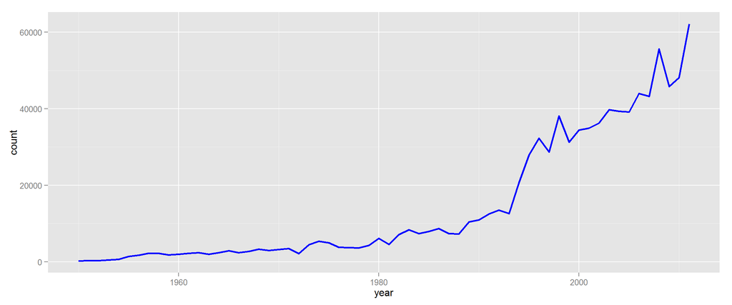

```r
rawdata$year = as.numeric(format(as.Date(rawdata$BGN_DATE, format="%m/%d/%Y %H:%M:%S"), "%Y"))
RecordsByYear = rawdata[, lapply(.SD,length), by=year, .SDcols=1]
setnames(RecordsByYear, 2, "count")
ggplot(RecordsByYear) + geom_line(aes(year, count), colour = 'blue', size = 1)
```

Based on the plot of the number of events captured per year, we conclude that during the first 4 decades the number of events captured is lower in comparison to the last 2 decades. In the mid 1990s we see a spike in the number of events beign captured. In order to avoid capturing partial data we decided to use data collected starting in 2001.

A new subset of data is created using the code below:

```r
data <- rawdata[year >= 2001]
```

The new subset of data from JAN-2001 to NOV-2011 contains 488692 rows as the information obtained using the code below:

```r
dim(data)
```

```
## [1] 488692     38
```

These recent years represent a little less than 18% of the total data collection period but include over 54% of the total data collected.

In order to combine property and crop damage, there is a need to standardize their numerical formats. The code below is used for that:

```r
data$PROPDMGEXP = as.character(data$PROPDMGEXP)
data$PROPDMGEXP[toupper(data$PROPDMGEXP) == 'B'] = "9"
data$PROPDMGEXP[toupper(data$PROPDMGEXP) == 'M'] = "6"
data$PROPDMGEXP[toupper(data$PROPDMGEXP) == 'K'] = "3"
data$PROPDMGEXP[toupper(data$PROPDMGEXP) == 'H'] = "2"
data$PROPDMGEXP = as.numeric(data$PROPDMGEXP)
data$PROPDMGEXP[is.na(data$PROPDMGEXP)] = 0
data$PropertyDamage = data$PROPDMG * 10^data$PROPDMGEXP
```

```r
data$CROPDMGEXP = as.character(data$CROPDMGEXP)
data$CROPDMGEXP[toupper(data$CROPDMGEXP) == 'B'] = "9"
data$CROPDMGEXP[toupper(data$CROPDMGEXP) == 'M'] = "6"
data$CROPDMGEXP[toupper(data$CROPDMGEXP) == 'K'] = "3"
data$CROPDMGEXP[toupper(data$CROPDMGEXP) == 'H'] = "2"
data$CROPDMGEXP[toupper(data$CROPDMGEXP) == ''] = "0"
data$CROPDMGEXP = as.numeric(data$CROPDMGEXP)
data$CROPDMGEXP[is.na(data$CROPDMGEXP)] = 0
data$CropDamage = data$CROPDMG * 10^data$CROPDMGEXP
```

The economic impact of weather events is defined as the sum of property damage and crop damage as the code below:

```r
data$TotalDamage = data$PropertyDamage + data$CropDamage
```

```r
unique(data$EVTYPE)
```

```
##   [1] TSTM WIND                      HAIL
##   [3] TORNADO                        FLASH FLOOD
##   [5] HIGH WIND                      FLOOD
##   [7] WILD/FOREST FIRE               WINTER STORM
##   [9] EXCESSIVE HEAT                 LIGHTNING
##  [11] FUNNEL CLOUD                   HEAVY SNOW
##  [13] EXTREME COLD                   WATERSPOUT
##  [15] COASTAL FLOODING               TROPICAL STORM
##  [17] TSTM WIND/HAIL                 HEAVY RAIN
##  [19] RIP CURRENTS                   HEAVY SURF
##  [21] AVALANCHE                      EXTREME WINDCHILL
##  [23] BLIZZARD                       ICE STORM
##  [25] VOLCANIC ASH                   LATE SEASON SNOW
##  [27] FOG                            URBAN/SML STREAM FLD
##  [29] DUST STORM                     WIND DAMAGE
```

[output cut: 71 more lines]

In order to clean up these categories we used the codes below to capture the majority of them. We did not attempt to capture 100% of them but the ones that represent most of the damage, and people impacted represented by the number of injuries and fatalities.

```r
tail(sort(tapply(data$TotalDamage, data$EVTYPE, sum)), n=50)
```

```
##            FREEZING FOG         COLD/WIND CHILL               AVALANCHE
##                 2182000                 2590000                 2766300
##              SMALL HAIL    URBAN/SML STREAM FLD              WATERSPOUT
##                 4650000                 4826200                 5228200
##                     FOG        MARINE TSTM WIND      WINTER WEATHER/MIX
##                 5258000                 5421000                 6372000
##              DUST STORM               DENSE FOG         LAKESHORE FLOOD
##                 7139000                 7319000                 7540000
## EXTREME COLD/WIND CHILL  ASTRONOMICAL HIGH TIDE    HEAVY SURF/HIGH SURF
##                 8698000                 9425000                 9870000
##       EXTREME WINDCHILL        COASTAL FLOODING          WINTER WEATHER
##                17000000                17093000                35847000
##        LAKE-EFFECT SNOW          TSTM WIND/HAIL                  FREEZE
##                40115000                46864550                47850000
##               HIGH SURF                BLIZZARD                 TSUNAMI
##                83344500               119973000               144082000
##            EXTREME COLD           COASTAL FLOOD             STRONG WIND
##               154993000               216820560               239212950
##        WILD/FOREST FIRE              HEAVY SNOW               LANDSLIDE
##               248059430               261536730               344095000
##          EXCESSIVE HEAT               LIGHTNING              HEAVY RAIN
##               496805200               561203560               861703040
##            FROST/FREEZE            WINTER STORM               ICE STORM
##              1103566000              1370919200              1983414800
##               TSTM WIND               HURRICANE       THUNDERSTORM WIND
##              2122507560              3486465010              3780985440
##        STORM SURGE/TIDE                WILDFIRE               HIGH WIND
##              4642038000              5054139800              5395255480
##                 DROUGHT          TROPICAL STORM             FLASH FLOOD
##              7543443000              7606531550             12179310210
##                    HAIL                 TORNADO             STORM SURGE
##             13203043160             19265009970             43169775000
##       HURRICANE/TYPHOON                   FLOOD
##             71913712800            137583726930
```

```r
data$EVTYPE[toupper(data$EVTYPE) %in%
c("TSTM WIND",
" TSTM WIND",
"SEVERE THUNDERSTORM WINDS",
"THUNDERSTORM WINDS")] = "THUNDERSTORM WIND"
data$EVTYPE[toupper(data$EVTYPE) %in%
c("HURRICANE/TYPHOON",
"HURRICANE OPAL",
"HURRICANE OPAL/HIGH WINDS",
"HURRICANE EMILY",
"TYPHOON",
"HURRICANE ERIN")] = "HURRICANE"
data$EVTYPE[toupper(data$EVTYPE) %in%
c("WILD/FOREST FIRE",
"WILDFIRES",
"WILD FIRES")] = "WILDFIRE"
data$EVTYPE[toupper(data$EVTYPE) %in%
c("HEAVY RAIN/SEVERE WEATHER",
"EXCESSIVE RAINFALL",
"UNSEASONAL RAIN",
"HEAVY RAINS")] = "HEAVY RAIN"
data$EVTYPE[toupper(data$EVTYPE) %in%
c("HIGH WINDS",
"HIGH WIND",
"BLOWING WIND",
"STRONG WINDS",
"STRONG WIND")] = "WIND"
data$EVTYPE[toupper(data$EVTYPE) %in%
c("STORM SURGE/TIDE"
)] = "STORM SURGE"
data$EVTYPE[toupper(data$EVTYPE) %in%
c("EXCESSIVE HEAT",
"HEAT WAVE",
"EXTREME HEAT",
"UNSEASONABLY WARM",
"RECORD/EXCESSIVE HEAT",
"RECORD HEAT")] = "HEAT"
data$EVTYPE[toupper(data$EVTYPE) %in%
c("EXTREME COLD",
"FROST/FREEZE",
"FROST",
"Early Frost ",
"DAMAGING FREEZE",
"RECORD COLD",
"COLD/WIND CHILL",
"EXTREME COLD/WIND CHILL",
"UNSEASONABLY COLD",
"Unseasonable Cold",
"HARD FREEZE",
"FREEZE")] = "COLD"
data$EVTYPE[toupper(data$EVTYPE) %in%
c("COASTAL FLOODING",
"COASTAL FLOODING/EROSION",
"COASTAL FLOODING/EROSION",
"Erosion/Cstl Flood",
"COASTAL FLOOD")] = "COASTAL FLOOD"
data$EVTYPE[toupper(data$EVTYPE) %in%
c("FLASH FLOODING",
"FLASH FLOOD/FLOOD",
"FLOOD/FLASH FLOOD")] = "FLASH FLOOD"
data$EVTYPE[toupper(data$EVTYPE) %in%
c("SMALL HAIL")] = "HAIL"
data$EVTYPE[toupper(data$EVTYPE) %in%
c("RIVER FLOODING"
)] = "RIVER FLOOD"
data$EVTYPE[toupper(data$EVTYPE) %in%
c("FLOODING",
"MAJOR FLOOD")] = "FLOOD"
```

```r
data$TotalPeople = data$INJURIES + data$FATALITIES
tail(sort(tapply(data$TotalPeople, data$EVTYPE, sum)), n=20)
```

```
##        DUST STORM               FOG      RIP CURRENTS         AVALANCHE
##               223               242               251               272
##              COLD        HEAVY SNOW    TROPICAL STORM    WINTER WEATHER
##               273               279               317               376
##      WINTER STORM              HAIL       RIP CURRENT             FLOOD
##               397               491               548               569
##              WIND          WILDFIRE       FLASH FLOOD         HURRICANE
##              1058              1178              1353              1359
##         LIGHTNING THUNDERSTORM WIND              HEAT           TORNADO
##              3036              3100              5550             15483
```

```r
data$EVTYPE[toupper(data$EVTYPE) %in%
c("TROPICAL STORM GORDON",
"TROPICAL STORM JERRY")] = "TROPICAL STORM"
data$EVTYPE[toupper(data$EVTYPE) %in%
c("DENSE FOG"
)] = "FOG"
data$EVTYPE[toupper(data$EVTYPE) %in%
c("WINTER STORMS"
)] = "WINTER STORM"
data$EVTYPE[toupper(data$EVTYPE) %in%
c("WATERSPOUT/TORNADO"
)] = "WATERSPOUT"
data$EVTYPE[toupper(data$EVTYPE) %in%
c("MARINE TSTM WIND"
)] = "MARINE THUNDERSTORM WIND"
data$EVTYPE[toupper(data$EVTYPE) %in%
c("RIP CURRENTS"
)] = "RIP CURRENT"
data$EVTYPE[toupper(data$EVTYPE) %in%
c("HEAVY SURF",
"HEAVY SURF/HIGH SURF")] = "HIGH SURF"
data$EVTYPE[toupper(data$EVTYPE) %in%
c("WINTRY MIX",
"WINTER WEATHER MIX",
"WINTER WEATHER/MIX")] = "WINTER WEATHER"
```

## *Results*

Due to the seasonality of some events we decided to aggregate the data by events and did not use the annual data.

The events were grouped according to:

### *A) Population Health Impact (Number of People Affected)*

For the 10 event types with most people affected we have the code below:

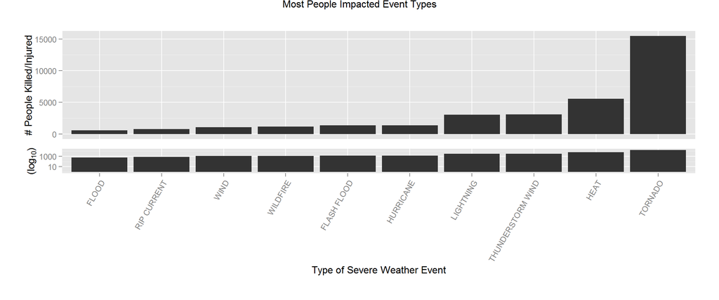

```r
people = as.data.frame.table(tail(sort(tapply(data$TotalPeople, data$EVTYPE, sum)), n=10))
colnames(people) = c("EventType", "TotalPeople")
p1 = ggplot(data=people, aes(x=EventType, y=TotalPeople)) +
theme(plot.margin=unit(c(1,1,-0.2,.90), "cm")) +
geom_bar(stat="identity") +
labs(x="", y="# People Killed/Injured")
p2 = p1 + scale_y_log10() +
theme(plot.margin=unit(c(-0.2,1,1,1), "cm")) +
theme(axis.text.x = element_text(angle = 60, hjust = 1)) +
labs(y=expression(paste("(", log[10], ")"))) +
xlab("Type of Severe Weather Event")
p1 = p1 + theme(axis.text.x = element_blank(), axis.ticks.x = element_blank())
grid.arrange(p1, p2, nrow=2, main="Most People Impacted Event Types")
```

### *B) Economic Impact (Cost of Damages)*

For the 10 event types per their economic impact we have the code below:

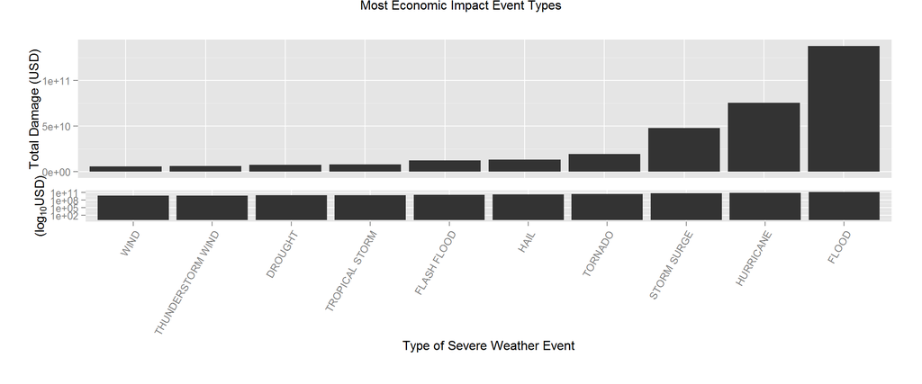

```r
destruction = as.data.frame.table(tail(sort(tapply(data$TotalDamage, data$EVTYPE, sum)), n=10))
colnames(destruction) = c("EventType", "TotalDamage")
p1 = ggplot(data=destruction, aes(x=EventType, y=TotalDamage)) +
theme(plot.margin=unit(c(1,1,-0.2,.82), "cm")) +
geom_bar(stat="identity") +
labs(x="", y="Total Damage (USD)")
p2 = p1 + scale_y_log10() +
theme(plot.margin=unit(c(-0.2,1,1,1), "cm")) +
theme(axis.text.x = element_text(angle = 60, hjust = 1)) +
labs(y=expression(paste("(", log[10], "USD)"))) +
xlab("Type of Severe Weather Event")
p1 = p1 + theme(axis.text.x = element_blank(), axis.ticks.x = element_blank())
grid.arrange(p1, p2, nrow=2, main="Most Economic Impact Event Types")
```

We hope that the information above would be useful to the government managers in order to plan in advance having in mind the minimization of both people and economic impact of the severe weather related events.

END OF REPORT.